# experiment analysis

```python
#missing values
```

some columns have a very high percentage of missing values. The following are the options for handling them:

1. Drop columns: We'd have to check the accuracy of the model with and without those columns
2. Imputation: Imputation is not an option because it will lead to specific values becoming overweighted in the buidlign of the tree
3. treat null as separate category: This is an option because while it can have the same problem as #2 above, there is a good possibility that certain values are more likely to be null for certain species. Hence, this could be a factor in the prediction (let's verify this in EDA)
4. Surrogate split: learn a little more about this and consider implementing it in the tree

```python
from scripts.final.DecisionTree import DecisionTree
from scripts.final.utils import *
import pandas as pd
import numpy as np
from ucimlrepo import fetch_ucirepo #for importing data
from summarytools import dfSummary
```

```python
# fetch dataset
secondary_mushroom = fetch_ucirepo(id=848)

# data (as pandas dataframes)
X_loaded = secondary_mushroom.data.features
y_loaded = secondary_mushroom.data.targets
```

```python
X = X_loaded.copy()
y = y_loaded.copy()
```

**Data Frame Summary**  
X  
Dimensions: 61,069 x 20  
Duplicates: 146

No

Variable

Stats / Values

Freqs / (% of Valid)

Graph

Missing

1

**cap-diameter**  
[float64]

Mean (sd) : 6.7 (5.3)  
min < med < max:  
0.4 < 5.9 < 62.3  
IQR (CV) : 5.1 (1.3)

2,571 distinct values

0  
(0.0%)

2

**cap-shape**  
[object]

1. x  
2. f  
3. s  
4. b  
5. o  
6. p  
7. c

26,934 (44.1%)  
13,404 (21.9%)  
7,164 (11.7%)  
5,694 (9.3%)  
3,460 (5.7%)  
2,598 (4.3%)  
1,815 (3.0%)

0  
(0.0%)

3

**cap-surface**  
[object]

1. nan  
2. t  
3. s  
4. y  
5. h  
6. g  
7. d  
8. e  
9. k  
10. i  
11. other

14,120 (23.1%)  
8,196 (13.4%)  
7,608 (12.5%)  
6,341 (10.4%)  
4,974 (8.1%)  
4,724 (7.7%)  
4,432 (7.3%)  
2,584 (4.2%)  
2,303 (3.8%)  
2,225 (3.6%)  
3,562 (5.8%)

14,120  
(23.1%)

4

**cap-color**  
[object]

1. n  
2. y  
3. w  
4. g  
5. e  
6. o  
7. r  
8. u  
9. p  
10. k  
11. other

24,218 (39.7%)  
8,543 (14.0%)  
7,666 (12.6%)  
4,420 (7.2%)  
4,035 (6.6%)  
3,656 (6.0%)  
1,782 (2.9%)  
1,709 (2.8%)  
1,703 (2.8%)  
1,279 (2.1%)  
2,058 (3.4%)

0  
(0.0%)

5

**does-bruise-or-bleed**  
[object]

1. f  
2. t

50,479 (82.7%)  
10,590 (17.3%)

0  
(0.0%)

6

**gill-attachment**  
[object]

1. a  
2. d  
3. nan  
4. x  
5. p  
6. e  
7. s  
8. f

12,698 (20.8%)  
10,247 (16.8%)  
9,884 (16.2%)  
7,413 (12.1%)  
6,001 (9.8%)  
5,648 (9.2%)  
5,648 (9.2%)  
3,530 (5.8%)

9,884  
(16.2%)

7

**gill-spacing**  
[object]

1. nan  
2. c  
3. d  
4. f

25,063 (41.0%)  
24,710 (40.5%)  
7,766 (12.7%)  
3,530 (5.8%)

25,063  
(41.0%)

8

**gill-color**  
[object]

1. w  
2. n  
3. y  
4. p  
5. g  
6. f  
7. o  
8. k  
9. r  
10. e  
11. other

18,521 (30.3%)  
9,645 (15.8%)  
9,546 (15.6%)  
5,983 (9.8%)  
4,118 (6.7%)  
3,530 (5.8%)  
2,909 (4.8%)  
2,375 (3.9%)  
1,399 (2.3%)  
1,066 (1.7%)  
1,977 (3.2%)

0  
(0.0%)

9

**stem-height**  
[float64]

Mean (sd) : 6.6 (3.4)  
min < med < max:  
0.0 < 6.0 < 33.9  
IQR (CV) : 3.1 (2.0)

2,226 distinct values

0  
(0.0%)

10

**stem-width**  
[float64]

Mean (sd) : 12.1 (10.0)  
min < med < max:  
0.0 < 10.2 < 103.9  
IQR (CV) : 11.4 (1.2)

4,630 distinct values

0  
(0.0%)

11

**stem-root**  
[object]

1. nan  
2. s  
3. b  
4. r  
5. f  
6. c

51,538 (84.4%)  
3,177 (5.2%)  
3,177 (5.2%)  
1,412 (2.3%)  
1,059 (1.7%)  
706 (1.2%)

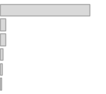

51,538  
(84.4%)

12

**stem-surface**  
[object]

1. nan  
2. s  
3. y  
4. i  
5. t  
6. g  
7. k  
8. f  
9. h

38,124 (62.4%)  
6,025 (9.9%)  
4,940 (8.1%)  
4,396 (7.2%)  
2,644 (4.3%)  
1,765 (2.9%)  
1,581 (2.6%)  
1,059 (1.7%)  
535 (0.9%)

38,124  
(62.4%)

13

**stem-color**  
[object]

1. w  
2. n  
3. y  
4. g  
5. o  
6. e  
7. u  
8. f  
9. p  
10. k  
11. other

22,926 (37.5%)  
18,063 (29.6%)  
7,865 (12.9%)  
2,626 (4.3%)  
2,187 (3.6%)  
2,050 (3.4%)  
1,490 (2.4%)  
1,059 (1.7%)  
1,025 (1.7%)  
837 (1.4%)  
941 (1.5%)

0  
(0.0%)

14

**veil-type**  
[object]

1. nan  
2. u

57,892 (94.8%)  
3,177 (5.2%)

57,892  
(94.8%)

15

**veil-color**  
[object]

1. nan  
2. w  
3. y  
4. n  
5. u  
6. k  
7. e

53,656 (87.9%)  
5,474 (9.0%)  
527 (0.9%)  
525 (0.9%)  
353 (0.6%)  
353 (0.6%)  
181 (0.3%)

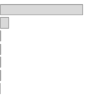

53,656  
(87.9%)

16

**has-ring**  
[object]

1. f  
2. t

45,890 (75.1%)  
15,179 (24.9%)

0  
(0.0%)

17

**ring-type**  
[object]

1. f  
2. nan  
3. e  
4. z  
5. l  
6. r  
7. p  
8. g  
9. m

48,361 (79.2%)  
2,471 (4.0%)  
2,435 (4.0%)  
2,118 (3.5%)  
1,427 (2.3%)  
1,399 (2.3%)  
1,265 (2.1%)  
1,240 (2.0%)  
353 (0.6%)

2,471  
(4.0%)

18

**spore-print-color**  
[object]

1. nan  
2. k  
3. p  
4. w  
5. n  
6. g  
7. u  
8. r

54,715 (89.6%)  
2,118 (3.5%)  
1,259 (2.1%)  
1,212 (2.0%)  
1,059 (1.7%)  
353 (0.6%)  
182 (0.3%)  
171 (0.3%)

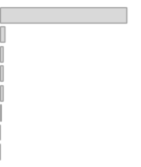

54,715  
(89.6%)

19

**habitat**  
[object]

1. d  
2. g  
3. l  
4. m  
5. h  
6. p  
7. w  
8. u

44,209 (72.4%)  
7,943 (13.0%)  
3,168 (5.2%)  
2,920 (4.8%)  
2,001 (3.3%)  
360 (0.6%)  
353 (0.6%)  
115 (0.2%)

0  
(0.0%)

20

**season**  
[object]

1. a  
2. u  
3. w  
4. s

30,177 (49.4%)  
22,898 (37.5%)  
5,267 (8.6%)  
2,727 (4.5%)

0  
(0.0%)

```python
dfSummary(X)
```

### Missing Values

Most of the columns do not have any missing values. None of the numeric columns have mssing values. However, missing values are particularly prominent in

1. spore-print-color: 89.6%
2. veil-type: 94.8%
3. veil-color: 87.9%
4. stem-root: 84.4%

Other columns with missing values include:

1. stem-surface: 62.4%
2. gill-spacing: 41%
3. cap-surface: 23.1%
4. gill-attachment: 16.2%
5. ring-type: 4%

Considering that very few values in the 4 listed columns above are present, it's unlikely we get any useful information from them. Hence, we drop these columns

```python
X = X.drop(['spore-print-color', 'veil-type', 'veil-color', 'stem-root'], axis=1)
```

We consider mode imputation for the other columns. However, research shows that mode imputation doesn't increase the predictive power of classification models: https://www.sciencedirect.com/science/article/pii/S2352914823002289#:~:text=Mode%20Imputation%3A%20This%20is%20one,of%20variance%20in%20the%20variable.

Besides, in these cases mode imputation could severely bias the data. For example, imputing the mode value of a for missing values in the gill attachment column will lead to having double the number of observations with the aaa gill attachment type as the d attachment type, while in the observations, it has only ~20% more data.

We also consider dropping all rows containing missing values in any column but this will lead to excessive loss of data

Thus, the method we adopt for the other fields is to consider the missing values as a separate category

To do this, we force convert all categorical columns to string, turning the missing values into string values with value 'nan'

```python
for col in X:
    X.loc[:,col]=X.loc[:,col].astype(str) if X.loc[:,col].dtype == 'object' else X.loc[:,col]
```

```python
dfSummary(X)
```

**Data Frame Summary**  
X  
Dimensions: 61,069 x 16  
Duplicates: 146

No

Variable

Stats / Values

Freqs / (% of Valid)

Graph

Missing

1

**cap-diameter**  
[float64]

Mean (sd) : 6.7 (5.3)  
min < med < max:  
0.4 < 5.9 < 62.3  
IQR (CV) : 5.1 (1.3)

2,571 distinct values

0  
(0.0%)

2

**cap-shape**  
[object]

1. x  
2. f  
3. s  
4. b  
5. o  
6. p  
7. c

26,934 (44.1%)  
13,404 (21.9%)  
7,164 (11.7%)  
5,694 (9.3%)  
3,460 (5.7%)  
2,598 (4.3%)  
1,815 (3.0%)

0  
(0.0%)

3

**cap-surface**  
[object]

1. nan  
2. t  
3. s  
4. y  
5. h  
6. g  
7. d  
8. e  
9. k  
10. i  
11. other

14,120 (23.1%)  
8,196 (13.4%)  
7,608 (12.5%)  
6,341 (10.4%)  
4,974 (8.1%)  
4,724 (7.7%)  
4,432 (7.3%)  
2,584 (4.2%)  
2,303 (3.8%)  
2,225 (3.6%)  
3,562 (5.8%)

0  
(0.0%)

4

**cap-color**  
[object]

1. n  
2. y  
3. w  
4. g  
5. e  
6. o  
7. r  
8. u  
9. p  
10. k  
11. other

24,218 (39.7%)  
8,543 (14.0%)  
7,666 (12.6%)  
4,420 (7.2%)  
4,035 (6.6%)  
3,656 (6.0%)  
1,782 (2.9%)  
1,709 (2.8%)  
1,703 (2.8%)  
1,279 (2.1%)  
2,058 (3.4%)

0  
(0.0%)

5

**does-bruise-or-bleed**  
[object]

1. f  
2. t

50,479 (82.7%)  
10,590 (17.3%)

0  
(0.0%)

6

**gill-attachment**  
[object]

1. a  
2. d  
3. nan  
4. x  
5. p  
6. e  
7. s  
8. f

12,698 (20.8%)  
10,247 (16.8%)  
9,884 (16.2%)  
7,413 (12.1%)  
6,001 (9.8%)  
5,648 (9.2%)  
5,648 (9.2%)  
3,530 (5.8%)

0  
(0.0%)

7

**gill-spacing**  
[object]

1. nan  
2. c  
3. d  
4. f

25,063 (41.0%)  
24,710 (40.5%)  
7,766 (12.7%)  
3,530 (5.8%)

0  
(0.0%)

8

**gill-color**  
[object]

1. w  
2. n  
3. y  
4. p  
5. g  
6. f  
7. o  
8. k  
9. r  
10. e  
11. other

18,521 (30.3%)  
9,645 (15.8%)  
9,546 (15.6%)  
5,983 (9.8%)  
4,118 (6.7%)  
3,530 (5.8%)  
2,909 (4.8%)  
2,375 (3.9%)  
1,399 (2.3%)  
1,066 (1.7%)  
1,977 (3.2%)

0  
(0.0%)

9

**stem-height**  
[float64]

Mean (sd) : 6.6 (3.4)  
min < med < max:  
0.0 < 6.0 < 33.9  
IQR (CV) : 3.1 (2.0)

2,226 distinct values

0  
(0.0%)

10

**stem-width**  
[float64]

Mean (sd) : 12.1 (10.0)  
min < med < max:  
0.0 < 10.2 < 103.9  
IQR (CV) : 11.4 (1.2)

4,630 distinct values

0  
(0.0%)

11

**stem-surface**  
[object]

1. nan  
2. s  
3. y  
4. i  
5. t  
6. g  
7. k  
8. f  
9. h

38,124 (62.4%)  
6,025 (9.9%)  
4,940 (8.1%)  
4,396 (7.2%)  
2,644 (4.3%)  
1,765 (2.9%)  
1,581 (2.6%)  
1,059 (1.7%)  
535 (0.9%)

0  
(0.0%)

12

**stem-color**  
[object]

1. w  
2. n  
3. y  
4. g  
5. o  
6. e  
7. u  
8. f  
9. p  
10. k  
11. other

22,926 (37.5%)  
18,063 (29.6%)  
7,865 (12.9%)  
2,626 (4.3%)  
2,187 (3.6%)  
2,050 (3.4%)  
1,490 (2.4%)  
1,059 (1.7%)  
1,025 (1.7%)  
837 (1.4%)  
941 (1.5%)

0  
(0.0%)

13

**has-ring**  
[object]

1. f  
2. t

45,890 (75.1%)  
15,179 (24.9%)

0  
(0.0%)

14

**ring-type**  
[object]

1. f  
2. nan  
3. e  
4. z  
5. l  
6. r  
7. p  
8. g  
9. m

48,361 (79.2%)  
2,471 (4.0%)  
2,435 (4.0%)  
2,118 (3.5%)  
1,427 (2.3%)  
1,399 (2.3%)  
1,265 (2.1%)  
1,240 (2.0%)  
353 (0.6%)

0  
(0.0%)

15

**habitat**  
[object]

1. d  
2. g  
3. l  
4. m  
5. h  
6. p  
7. w  
8. u

44,209 (72.4%)  
7,943 (13.0%)  
3,168 (5.2%)  
2,920 (4.8%)  
2,001 (3.3%)  
360 (0.6%)  
353 (0.6%)  
115 (0.2%)

0  
(0.0%)

16

**season**  
[object]

1. a  
2. u  
3. w  
4. s

30,177 (49.4%)  
22,898 (37.5%)  
5,267 (8.6%)  
2,727 (4.5%)

0  
(0.0%)

We now have 16 columns and no missing values

### Encoding Values

We consider the two encoding methods:

1. One-hot encoding: One-hot encoding is inappropriate for this type of dataset which contains mainly categorical columns because it will lead to the creation of too many columns
2. Label encoding: Label encoding would work fine for this kind of dataset. However, we have to be careful to ensure that the numeric values are not treated as if they carry an ordinal value. An evaluation of the dataset shows that none of the fields could be considered as having an ordinal value. Hence, we want our decision tree to handle them separately. However, numeric encoding would make it difficult to recognize this during the training of our decision tree. So label encoding could make the tree run faster, the results could be inaccurate if the tree considers the numeric values ordinally.

Hence, to allow correct handling of categorical variables, we do not encode the predictors. However, we can encode the predicted variable y numerically where this is not a concern.

```python
#encode y into 0s and 1s.
y_mapping = encode_labels(y)
print(y_mapping)
```

```
{'class': {'e': 0, 'p': 1}}
```

Thus our data assigns the value of 1 when the mushroom is poisonous and 0 when it is not.

### Splitting the data

Having decided on the set of features to train on, we split our data into train and test sets to begin training

```python
#split dataset into train and test
X_train, X_test, y_train, y_test = train_test_split(X, y, test_size=0.2, random_state=42)
```

Now we train the tree using each of the three splitting methods

```python
dfSummary(X)
```

**Data Frame Summary**  
X  
Dimensions: 61,069 x 16  
Duplicates: 146

No

Variable

Stats / Values

Freqs / (% of Valid)

Graph

Missing

1

**cap-diameter**  
[float64]

Mean (sd) : 6.7 (5.3)  
min < med < max:  
0.4 < 5.9 < 62.3  
IQR (CV) : 5.1 (1.3)

2,571 distinct values

0  
(0.0%)

2

**cap-shape**  
[object]

1. x  
2. f  
3. s  
4. b  
5. o  
6. p  
7. c

26,934 (44.1%)  
13,404 (21.9%)  
7,164 (11.7%)  
5,694 (9.3%)  
3,460 (5.7%)  
2,598 (4.3%)  
1,815 (3.0%)

0  
(0.0%)

3

**cap-surface**  
[object]

1. nan  
2. t  
3. s  
4. y  
5. h  
6. g  
7. d  
8. e  
9. k  
10. i  
11. other

14,120 (23.1%)  
8,196 (13.4%)  
7,608 (12.5%)  
6,341 (10.4%)  
4,974 (8.1%)  
4,724 (7.7%)  
4,432 (7.3%)  
2,584 (4.2%)  
2,303 (3.8%)  
2,225 (3.6%)  
3,562 (5.8%)

0  
(0.0%)

4

**cap-color**  
[object]

1. n  
2. y  
3. w  
4. g  
5. e  
6. o  
7. r  
8. u  
9. p  
10. k  
11. other

24,218 (39.7%)  
8,543 (14.0%)  
7,666 (12.6%)  
4,420 (7.2%)  
4,035 (6.6%)  
3,656 (6.0%)  
1,782 (2.9%)  
1,709 (2.8%)  
1,703 (2.8%)  
1,279 (2.1%)  
2,058 (3.4%)

0  
(0.0%)

5

**does-bruise-or-bleed**  
[object]

1. f  
2. t

50,479 (82.7%)  
10,590 (17.3%)

0  
(0.0%)

6

**gill-attachment**  
[object]

1. a  
2. d  
3. nan  
4. x  
5. p  
6. e  
7. s  
8. f

12,698 (20.8%)  
10,247 (16.8%)  
9,884 (16.2%)  
7,413 (12.1%)  
6,001 (9.8%)  
5,648 (9.2%)  
5,648 (9.2%)  
3,530 (5.8%)

0  
(0.0%)

7

**gill-spacing**  
[object]

1. nan  
2. c  
3. d  
4. f

25,063 (41.0%)  
24,710 (40.5%)  
7,766 (12.7%)  
3,530 (5.8%)

0  
(0.0%)

8

**gill-color**  
[object]

1. w  
2. n  
3. y  
4. p  
5. g  
6. f  
7. o  
8. k  
9. r  
10. e  
11. other

18,521 (30.3%)  
9,645 (15.8%)  
9,546 (15.6%)  
5,983 (9.8%)  
4,118 (6.7%)  
3,530 (5.8%)  
2,909 (4.8%)  
2,375 (3.9%)  
1,399 (2.3%)  
1,066 (1.7%)  
1,977 (3.2%)

0  
(0.0%)

9

**stem-height**  
[float64]

Mean (sd) : 6.6 (3.4)  
min < med < max:  
0.0 < 6.0 < 33.9  
IQR (CV) : 3.1 (2.0)

2,226 distinct values

0  
(0.0%)

10

**stem-width**  
[float64]

Mean (sd) : 12.1 (10.0)  
min < med < max:  
0.0 < 10.2 < 103.9  
IQR (CV) : 11.4 (1.2)

4,630 distinct values

0  
(0.0%)

11

**stem-surface**  
[object]

1. nan  
2. s  
3. y  
4. i  
5. t  
6. g  
7. k  
8. f  
9. h

38,124 (62.4%)  
6,025 (9.9%)  
4,940 (8.1%)  
4,396 (7.2%)  
2,644 (4.3%)  
1,765 (2.9%)  
1,581 (2.6%)  
1,059 (1.7%)  
535 (0.9%)

0  
(0.0%)

12

**stem-color**  
[object]

1. w  
2. n  
3. y  
4. g  
5. o  
6. e  
7. u  
8. f  
9. p  
10. k  
11. other

22,926 (37.5%)  
18,063 (29.6%)  
7,865 (12.9%)  
2,626 (4.3%)  
2,187 (3.6%)  
2,050 (3.4%)  
1,490 (2.4%)  
1,059 (1.7%)  
1,025 (1.7%)  
837 (1.4%)  
941 (1.5%)

0  
(0.0%)

13

**has-ring**  
[object]

1. f  
2. t

45,890 (75.1%)  
15,179 (24.9%)

0  
(0.0%)

14

**ring-type**  
[object]

1. f  
2. nan  
3. e  
4. z  
5. l  
6. r  
7. p  
8. g  
9. m

48,361 (79.2%)  
2,471 (4.0%)  
2,435 (4.0%)  
2,118 (3.5%)  
1,427 (2.3%)  
1,399 (2.3%)  
1,265 (2.1%)  
1,240 (2.0%)  
353 (0.6%)

0  
(0.0%)

15

**habitat**  
[object]

1. d  
2. g  
3. l  
4. m  
5. h  
6. p  
7. w  
8. u

44,209 (72.4%)  
7,943 (13.0%)  
3,168 (5.2%)  
2,920 (4.8%)  
2,001 (3.3%)  
360 (0.6%)  
353 (0.6%)  
115 (0.2%)

0  
(0.0%)

16

**season**  
[object]

1. a  
2. u  
3. w  
4. s

30,177 (49.4%)  
22,898 (37.5%)  
5,267 (8.6%)  
2,727 (4.5%)

0  
(0.0%)

Model 1

```python
import numpy as np
from collections import Counter
from typing import Optional

class Node:
    def __init__(self, feature: Optional[int] = None, threshold=None, left=None, right=None, *, value=None):
        self.feature = feature
        self.threshold = threshold
        self.left = left
        self.right = right
        self.value = value

    def is_leaf_node(self):
        return self.value is not None

class DecisionTree:
    def __init__(self, min_samples_split=2, max_depth=10, n_features=None, split_using="entropy"):
        if split_using not in ('entropy', 'gini', 'train_error'):
            raise ValueError(f"split_using argument must be one of ('entropy', 'gini', 'train_error')")
        self.min_samples_split = min_samples_split
        self.max_depth = max_depth
        self.n_features = n_features
        self.root = None
        self.split_using = split_using

    def fit(self, X, y):
        X = np.asarray(X)
        y = np.asarray(y)
        self.leaves = []
        self.n_features = X.shape[1] if not self.n_features else min(X.shape[1], self.n_features)
        self.root = self._grow_tree(X, y)

    def _grow_tree(self, X, y, depth=0):
        n_samples, n_labels = len(y), len(np.unique(y))

        if depth >= self.max_depth or n_labels == 1 or n_samples < self.min_samples_split:
            leaf_value = self._most_common_label(y)
            self.leaves.append(leaf_value)
            return Node(value=leaf_value)

        feat_idxs = np.random.choice(self.n_features, self.n_features, replace=False)
        best_feature, best_thresh, best_gain = self._best_split(X, y, feat_idxs)
        if best_gain == 0:
            leaf_value = self._most_common_label(y)
            self.leaves.append(leaf_value)
            return Node(value=leaf_value)

        left_idxs, right_idxs = self._split(X[:, best_feature], best_thresh)
        left = self._grow_tree(X[left_idxs, :], y[left_idxs], depth + 1)
        right = self._grow_tree(X[right_idxs, :], y[right_idxs], depth + 1)
        return Node(best_feature, best_thresh, left, right)

    def _best_split(self, X, y, feat_idxs):
        best_gain = -1
        split_idx, split_threshold = None, None

        for feat_idx in feat_idxs:
            X_column = X[:, feat_idx]
            thresholds = np.unique(X_column)

            for thr in thresholds:
                gain = self._gain(y, X_column, thr)
                if gain > best_gain:
                    best_gain = gain
                    split_idx = feat_idx
                    split_threshold = thr

        return split_idx, split_threshold, best_gain

    def _gain(self, y, X_column, threshold):
        parent_metric = self._entropy(y) if self.split_using == 'entropy' else self._gini(y)
        left_idxs, right_idxs = self._split(X_column, threshold)

        if len(left_idxs) == 0 or len(right_idxs) == 0:
            return 0

        n, n_l, n_r = len(y), len(left_idxs), len(right_idxs)
        metric_l = self._entropy(y[left_idxs]) if self.split_using == 'entropy' else self._gini(y[left_idxs])
        metric_r = self._entropy(y[right_idxs]) if self.split_using == 'entropy' else self._gini(y[right_idxs])
        child_metric = (n_l / n) * metric_l + (n_r / n) * metric_r

        information_gain = parent_metric - child_metric
        return information_gain

    def _split(self, X_column, split_thresh):
        left_idxs = np.where(X_column <= split_thresh)[0]
        right_idxs = np.where(X_column > split_thresh)[0]
        return left_idxs, right_idxs

    def _entropy(self, y):
        counter = Counter(y)
        ps = np.array([count / len(y) for count in counter.values()])
        return -np.sum(ps * np.log2(ps + 1e-9))  # Added epsilon to avoid log(0)

    def _gini(self, y):
        counter = Counter(y)
        ps = np.array([count / len(y) for count in counter.values()])
        return 1 - np.sum(ps ** 2)

    def _most_common_label(self, y):
        return Counter(y).most_common(1)[0][0]

    def predict(self, X):
        return np.array([self._traverse_tree(x, self.root) for x in X])

    def _traverse_tree(self, x, node):
        if node.is_leaf_node():
            return node.value
        if x[node.feature] <= node.threshold:
            return self._traverse_tree(x, node.left)
        return self._traverse_tree(x, node.right)
```

```python
#training the decision tree
entropy_model = DecisionTree(split_using='entropy', max_depth=10)
entropy_model.fit(X_train, y_train)
```

```python
# for thr in thresholds:
#     if type(thr) == float:
#         print(type(thr))
```

```python
# for col in range(X_train.shape[1]):
#     X_column = X_train[:, col]
#     thresholds = np.unique(X_column.astype(str)) if entropy_model._iscategorical(X_column) else np.unique(X_column)
#     try:
#         X_column = X_column.astype(float)
#         for thr in thresholds:
#             print(f"col: {col}, thr: {thr}")
#             lol = np.argwhere(X_column <= thr).flatten()

#     except ValueError:
#         for thr in thresholds:
#             print(f"col: {col}, thr: {thr}")
#             lol = np.argwhere(X_column == thr).flatten()
```

```python
#performance of entropy model
entropy_pred = entropy_model.predict(X_test)
print(accuracy(y_test, entropy_pred))
print(precision(y_test, entropy_pred))
print(recall(y_test, entropy_pred))
```

```
Accuracy: 0.8711314884558703
Precision: 0.9340586877678866
Recall: 0.8283625730994152
```

Model 2: Gini impurity

```python
#training the decision tree
gini_model = DecisionTree(split_using='gini', max_depth=10)
gini_model.fit(X_train, y_train)
```

```python
#performance of gini model
gini_pred = gini_model.predict(X_test)
print(accuracy(y_test, gini_pred))
print(precision(y_test, gini_pred))
print(recall(y_test, gini_pred))
```

```
Accuracy: 0.9259865727853284
Precision: 0.970662860767523
Recall: 0.8948830409356725
```

Model 3: Train Error

```python
#training the decision tree
train_error_model = DecisionTree(split_using='train_error', max_depth=10)
train_error_model.fit(X_train, y_train)
```

```python
#performance of train_error model
train_error_pred = train_error_model.predict(X_test)
print(accuracy(y_test, train_error_pred))
print(precision(y_test, train_error_pred))
print(recall(y_test, train_error_pred))
```

```
Accuracy: 0.9260684460455215
Precision: 0.9708168120539254
Recall: 0.8948830409356725
```

```python
#training errors of each model
entropy_train = entropy_model.predict(X_train)
gini_train = gini_model.predict(X_train)
train_error_train = train_error_model.predict(X_train)
print(f"entropy train error: {zero_one_loss(y_train, entropy_train)}")
print(f"gini train error: {zero_one_loss(y_train, gini_train)}")
print(f"train_error train error: {zero_one_loss(y_train, train_error_train)}")
```

```
entropy train error: 0.11955787534540989
gini train error: 0.06691229147477229
train_error train error: 0.06691229147477229
```

It's easy to see that the training errors are similar to the test errors, showing that the model didn't overfit considering the stopping criteria.

finally we perform hyper parameter tuning to optimize the model on the max depth stopping criterion

```python
#tuning the tree on the max_depth criterion

tuned_tree = tune(X_train, y_train, tune_on='max_depth',split_using='gini', start=10, stop=15)
```

```
tree depth: 10, validation error: 0.07307338041142156
tree depth: 11, validation error: 0.04636168252993552
tree depth: 12, validation error: 0.0289632586224542
tree depth: 13, validation error: 0.014839832156381128
tree depth: 14, validation error: 0.009517961314092724
training error: 0.009517961314092724
```

```python
#tryna see if at some point the validation starts to rise
#tuning the tree on the max_depth criterion

tuned_tree = tune(X_train, y_train, tune_on='max_depth',split_using='gini', start=15, stop=25)
```

```
tree depth: 15, validation error: 0.010336710674444785
tree depth: 16, validation error: 0.008801555623784669
tree depth: 17, validation error: 0.006242963872684475
tree depth: 18, validation error: 0.0066523385528605055
tree depth: 19, validation error: 0.005935932862552451
tree depth: 20, validation error: 0.004707808822024357
tree depth: 21, validation error: 0.005117183502200389
tree depth: 22, validation error: 0.005117183502200389
tree depth: 23, validation error: 0.005833589192508443
tree depth: 24, validation error: 0.004810152492068366
training error: 0.004707808822024357
```

```python
#retraining the tree with the best validation error
best_tree = DecisionTree(max_depth=20, split_using='gini')
best_tree.fit(X_train, y_train)
```

```python
y_pred = best_tree.predict(X_test)
print(accuracy(y_test, y_pred))
print(precision(y_test, y_pred))
print(recall(y_test, y_pred))
```

```
Accuracy: 0.997789421974783
Precision: 0.9980991373007749
Recall: 0.997953216374269
```

```python
y_pred = best_tree.predict(X_test)
```

```python
print(accuracy(y_test, y_pred))
print(precision(y_test, y_pred))
print(recall(y_test, y_pred))
```

[output not shown]